# 3-phase VSI

1. Plot pole voltage ($V_{a0}$), line-to-line voltage ($V_{ab}$), phase voltage ($V_{an}$), and neutral voltage ($V_{n0}$).
2. Determine the RMS values of the fundamental components of phase voltage and load current.
3. Determine the power delivered to the load.
4. What is the average current drawn from the DC supply?
5. Which are the dominant harmonics present in the load current?

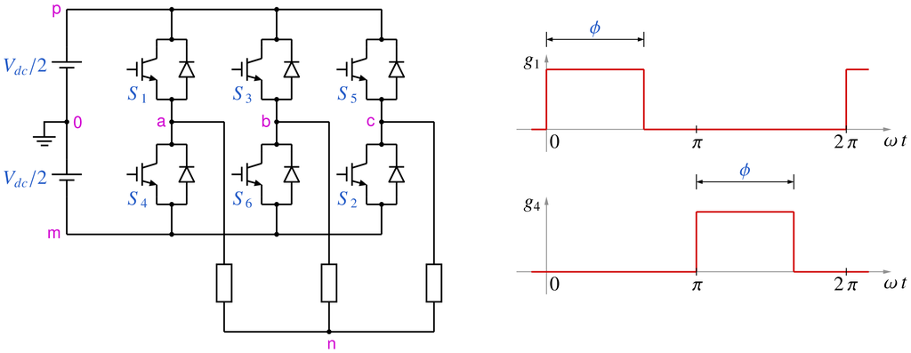

```python
from IPython.display import Image
Image(filename =r'VSI_3ph_2_fig_1.png', width=800)
```

```python
# run this cell to view the circuit file.
%pycat VSI_3ph_2_orig.in
```

We now replace the strings such as \$Vdc, \$L, with the values of our choice by running the python script given below. It takes an existing circuit file `VSI_3ph_2_orig.in` and produces a new circuit file `VSI_3ph_2.in`, after replacing \$Vdcby2, \$L, etc. with values of our choice.

```python
import gseim_calc as calc
Vdc = 600.0
s_Vdcby2 = ("%11.4E"%(Vdc/2)).strip()
f_clock = 50.0
s_f_clock = ("%11.4E"%(f_clock)).strip()
T = 1/f_clock
s_2T = ("%11.4E"%(2.0*T)).strip()

phi = 120.0
D1 = phi/360.0
s_D1 = ("%11.4E"%(D1)).strip()

s_R = "10"

l = [
  ('$Vdcby2', s_Vdcby2),
  ('$R', s_R),
  ('$f_clock', s_f_clock),
  ('$D1', s_D1),
  ('$2T', s_2T)
]
calc.replace_strings_1("VSI_3ph_2_orig.in", "VSI_3ph_2.in", l)
print('VSI_3ph_2.in is ready for execution')
```

```
VSI_3ph_2.in is ready for execution
```

**Execute the following cell to run GSEIM on VSI_3ph_2.in.**

```python
import os
import dos_unix
# uncomment for windows:
#dos_unix.d2u("VSI_3ph_2.in")
os.system('run_gseim VSI_3ph_2.in')
```

```
Circuit: filename = VSI_3ph_2.in
main: calling solve_trns
Transient simulation starts...
i=0
GSEIM: Program completed.
```

```
0
```

The circuit file (`VSI_3ph_2.in`) is created in the same directory as that used for launching Jupyter notebook. The last step (i.e., running `GSEIM` on `VSI_3ph_2.in`) creates data files called `VSI_3ph_2_1.dat`, etc. in the same directory. We can now use the python code below to compute/plot the various quantities of interest.

```
filename: VSI_3ph_2_1.dat
filename: VSI_3ph_2_2.dat
filename: VSI_3ph_2_3.dat
```

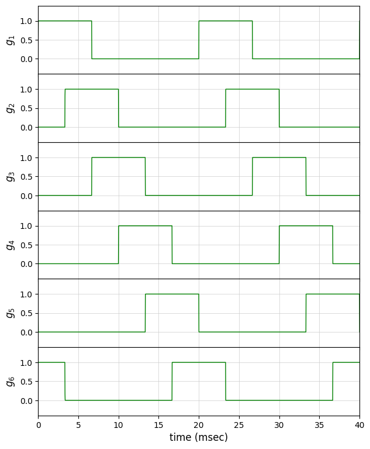

```python
import numpy as np
import matplotlib.pyplot as plt
import gseim_calc as calc
from setsize import set_size

slv = calc.slv("VSI_3ph_2.in")

i_slv = 0
i_out = 0
filename = slv.l_filename_all[i_slv][i_out]
print('filename:', filename)
u1 = np.loadtxt(filename)
t1 = u1[:, 0]

g1 = slv.get_array_double(i_slv,i_out,"g1",u1)
g2 = slv.get_array_double(i_slv,i_out,"g2",u1)
g3 = slv.get_array_double(i_slv,i_out,"g3",u1)
g4 = slv.get_array_double(i_slv,i_out,"g4",u1)
g5 = slv.get_array_double(i_slv,i_out,"g5",u1)
g6 = slv.get_array_double(i_slv,i_out,"g6",u1)

# since we have stored two cycles, we need to divide the last time point
# by 2 to get the period:

T = t1[-1]/2

i_out = 1
filename = slv.l_filename_all[i_slv][i_out]
print('filename:', filename)
u2 = np.loadtxt(filename)
t2 = u2[:, 0]

v_a0 = slv.get_array_double(i_slv,i_out,"v_a0",u2)
v_b0 = slv.get_array_double(i_slv,i_out,"v_b0",u2)
v_c0 = slv.get_array_double(i_slv,i_out,"v_c0",u2)
v_ab = slv.get_array_double(i_slv,i_out,"v_ab",u2)
v_bc = slv.get_array_double(i_slv,i_out,"v_bc",u2)
v_ca = slv.get_array_double(i_slv,i_out,"v_ca",u2)
v_an = slv.get_array_double(i_slv,i_out,"v_an",u2)
v_bn = slv.get_array_double(i_slv,i_out,"v_bn",u2)
v_cn = slv.get_array_double(i_slv,i_out,"v_cn",u2)
v_n0 = slv.get_array_double(i_slv,i_out,"v_n0",u2)

i_out = 2
filename = slv.l_filename_all[i_slv][i_out]
print('filename:', filename)
u3 = np.loadtxt(filename)
t3 = u3[:, 0]

IRa  = slv.get_array_double(i_slv,i_out,"IRa",u3)
IRb  = slv.get_array_double(i_slv,i_out,"IRb",u3)
IRc  = slv.get_array_double(i_slv,i_out,"IRc",u3)
IS1  = slv.get_array_double(i_slv,i_out,"IS1",u3)
P_Ra = slv.get_array_double(i_slv,i_out,"P_Ra",u3)
P_Rb = slv.get_array_double(i_slv,i_out,"P_Rb",u3)
P_Rc = slv.get_array_double(i_slv,i_out,"P_Rc",u3)

color1='green'

fig, ax = plt.subplots(6, sharex=False)
plt.subplots_adjust(wspace=0, hspace=0.0)

set_size(5.5, 7, ax[0])

for i in range(6):
    ax[i].set_xlim(left=0, right=2.0*T*1e3)
    ax[i].set_ylim(bottom=-0.4, top=1.4)
    ax[i].grid(color='#CCCCCC', linestyle='solid', linewidth=0.5)

ax[0].plot(t1*1e3, g1, color=color1, linewidth=1.0)
ax[1].plot(t1*1e3, g2, color=color1, linewidth=1.0)
ax[2].plot(t1*1e3, g3, color=color1, linewidth=1.0)
ax[3].plot(t1*1e3, g4, color=color1, linewidth=1.0)
ax[4].plot(t1*1e3, g5, color=color1, linewidth=1.0)
ax[5].plot(t1*1e3, g6, color=color1, linewidth=1.0)

ax[0].set_ylabel(r'$g_1$', fontsize=12)
ax[1].set_ylabel(r'$g_2$', fontsize=12)
ax[2].set_ylabel(r'$g_3$', fontsize=12)
ax[3].set_ylabel(r'$g_4$', fontsize=12)
ax[4].set_ylabel(r'$g_5$', fontsize=12)
ax[5].set_ylabel(r'$g_6$', fontsize=12)

ax[5].set_xlabel('time (msec)', fontsize=12)

ax[0].tick_params(labelbottom=False)
ax[1].tick_params(labelbottom=False)
ax[2].tick_params(labelbottom=False)
ax[3].tick_params(labelbottom=False)
ax[4].tick_params(labelbottom=False)

#plt.tight_layout()
plt.show()
```

```
filename: VSI_3ph_2_1.dat
filename: VSI_3ph_2_2.dat
filename: VSI_3ph_2_3.dat
average power delivered to load:  1.8001E+04
average DC supply current:  3.0000E+01
```

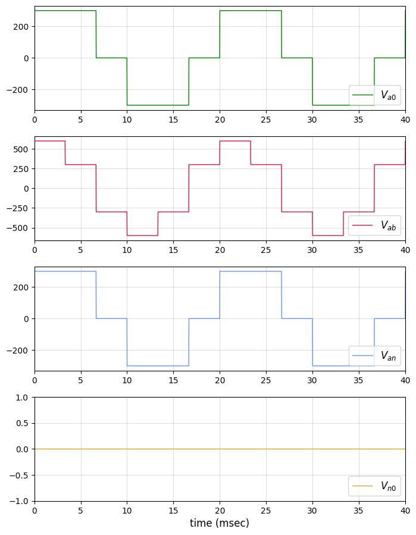

```python
import numpy as np
import matplotlib.pyplot as plt
import gseim_calc as calc
from setsize import set_size

slv = calc.slv("VSI_3ph_2.in")

i_slv = 0
i_out = 0
filename = slv.l_filename_all[i_slv][i_out]
print('filename:', filename)
u1 = np.loadtxt(filename)
t1 = u1[:, 0]

g1 = slv.get_array_double(i_slv,i_out,"g1",u1)
g2 = slv.get_array_double(i_slv,i_out,"g2",u1)
g3 = slv.get_array_double(i_slv,i_out,"g3",u1)
g4 = slv.get_array_double(i_slv,i_out,"g4",u1)
g5 = slv.get_array_double(i_slv,i_out,"g5",u1)
g6 = slv.get_array_double(i_slv,i_out,"g6",u1)

# since we have stored two cycles, we need to divide the last time point
# by 2 to get the period:

T = t1[-1]/2

i_out = 1
filename = slv.l_filename_all[i_slv][i_out]
print('filename:', filename)
u2 = np.loadtxt(filename)
t2 = u2[:, 0]

v_a0 = slv.get_array_double(i_slv,i_out,"v_a0",u2)
v_b0 = slv.get_array_double(i_slv,i_out,"v_b0",u2)
v_c0 = slv.get_array_double(i_slv,i_out,"v_c0",u2)
v_ab = slv.get_array_double(i_slv,i_out,"v_ab",u2)
v_bc = slv.get_array_double(i_slv,i_out,"v_bc",u2)
v_ca = slv.get_array_double(i_slv,i_out,"v_ca",u2)
v_an = slv.get_array_double(i_slv,i_out,"v_an",u2)
v_bn = slv.get_array_double(i_slv,i_out,"v_bn",u2)
v_cn = slv.get_array_double(i_slv,i_out,"v_cn",u2)
v_n0 = slv.get_array_double(i_slv,i_out,"v_n0",u2)

i_out = 2
filename = slv.l_filename_all[i_slv][i_out]
print('filename:', filename)
u3 = np.loadtxt(filename)
t3 = u3[:, 0]

IRa  = slv.get_array_double(i_slv,i_out,"IRa",u3)
IRb  = slv.get_array_double(i_slv,i_out,"IRb",u3)
IRc  = slv.get_array_double(i_slv,i_out,"IRc",u3)
IS1  = slv.get_array_double(i_slv,i_out,"IS1",u3)
P_Ra = slv.get_array_double(i_slv,i_out,"P_Ra",u3)
P_Rb = slv.get_array_double(i_slv,i_out,"P_Rb",u3)
P_Rc = slv.get_array_double(i_slv,i_out,"P_Rc",u3)

l_IS1   = calc.avg_rms_3a(t3, IS1 , T, 2.0*T, 1.0e-4*T)
l_P_Ra  = calc.avg_rms_3a(t3, P_Ra, T, 2.0*T, 1.0e-4*T)

print('average power delivered to load:', "%11.4E"%(3.0*l_P_Ra[0]))
print('average DC supply current:', "%11.4E"%l_IS1[0])

color1='green'
color2='crimson'
color3='cornflowerblue'
color4='goldenrod'
color5='blue'

fig, ax = plt.subplots(4, sharex=False)
plt.subplots_adjust(wspace=0, hspace=0.0)

set_size(5.5, 7, ax[0])

for i in range(4):
    ax[i].set_xlim(left=0, right=2.0*T*1e3)
    ax[i].grid(color='#CCCCCC', linestyle='solid', linewidth=0.5)

ax[0].plot(t2*1e3, v_a0, color=color1, linewidth=1.0, label="$V_{a0}$")
ax[1].plot(t2*1e3, v_ab, color=color2, linewidth=1.0, label="$V_{ab}$")
ax[2].plot(t2*1e3, v_an, color=color3, linewidth=1.0, label="$V_{an}$")
ax[3].plot(t2*1e3, v_n0, color=color4, linewidth=1.0, label="$V_{n0}$")

ax[3].set_ylim(bottom=-1, top=1)
ax[3].set_xlabel('time (msec)', fontsize=12)

for i in range(4):
    ax[i].legend(loc = 'lower right',frameon = True, fontsize = 10, title = None,
      markerfirst = True, markerscale = 1.0, labelspacing = 0.5, columnspacing = 2.0,
      prop = {'size' : 12},)

plt.tight_layout()
plt.show()
```

```
filename: VSI_3ph_2_1.dat
filename: VSI_3ph_2_2.dat
filename: VSI_3ph_2_3.dat
```

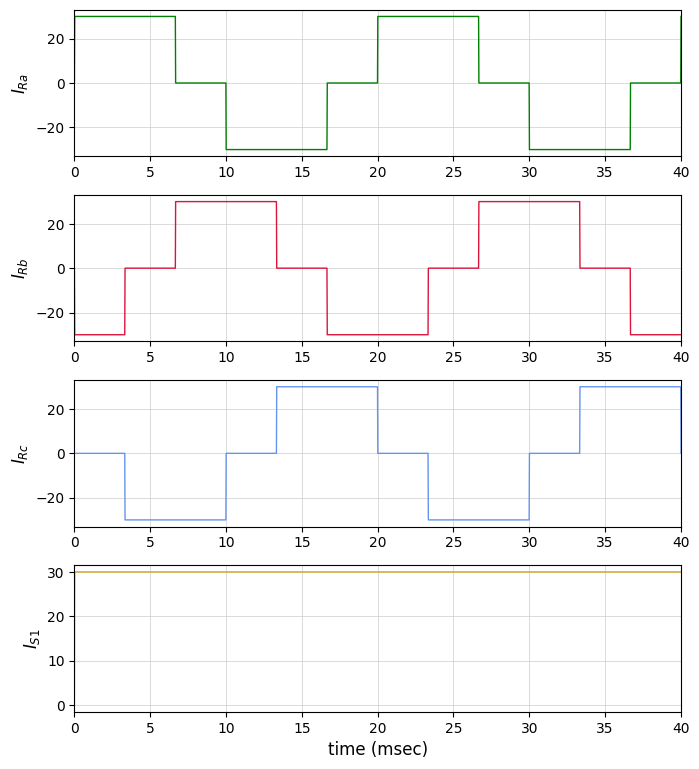

```python
import numpy as np
import matplotlib.pyplot as plt
import gseim_calc as calc
from setsize import set_size

slv = calc.slv("VSI_3ph_2.in")

i_slv = 0
i_out = 0
filename = slv.l_filename_all[i_slv][i_out]
print('filename:', filename)
u1 = np.loadtxt(filename)
t1 = u1[:, 0]

g1 = slv.get_array_double(i_slv,i_out,"g1",u1)
g2 = slv.get_array_double(i_slv,i_out,"g2",u1)
g3 = slv.get_array_double(i_slv,i_out,"g3",u1)
g4 = slv.get_array_double(i_slv,i_out,"g4",u1)
g5 = slv.get_array_double(i_slv,i_out,"g5",u1)
g6 = slv.get_array_double(i_slv,i_out,"g6",u1)

# since we have stored two cycles, we need to divide the last time point
# by 2 to get the period:

T = t1[-1]/2

i_out = 1
filename = slv.l_filename_all[i_slv][i_out]
print('filename:', filename)
u2 = np.loadtxt(filename)
t2 = u2[:, 0]

v_a0 = slv.get_array_double(i_slv,i_out,"v_a0",u2)
v_b0 = slv.get_array_double(i_slv,i_out,"v_b0",u2)
v_c0 = slv.get_array_double(i_slv,i_out,"v_c0",u2)
v_ab = slv.get_array_double(i_slv,i_out,"v_ab",u2)
v_bc = slv.get_array_double(i_slv,i_out,"v_bc",u2)
v_ca = slv.get_array_double(i_slv,i_out,"v_ca",u2)
v_an = slv.get_array_double(i_slv,i_out,"v_an",u2)
v_bn = slv.get_array_double(i_slv,i_out,"v_bn",u2)
v_cn = slv.get_array_double(i_slv,i_out,"v_cn",u2)
v_n0 = slv.get_array_double(i_slv,i_out,"v_n0",u2)

i_out = 2
filename = slv.l_filename_all[i_slv][i_out]
print('filename:', filename)
u3 = np.loadtxt(filename)
t3 = u3[:, 0]

IRa  = slv.get_array_double(i_slv,i_out,"IRa",u3)
IRb  = slv.get_array_double(i_slv,i_out,"IRb",u3)
IRc  = slv.get_array_double(i_slv,i_out,"IRc",u3)
IS1  = slv.get_array_double(i_slv,i_out,"IS1",u3)
P_Ra = slv.get_array_double(i_slv,i_out,"P_Ra",u3)
P_Rb = slv.get_array_double(i_slv,i_out,"P_Rb",u3)
P_Rc = slv.get_array_double(i_slv,i_out,"P_Rc",u3)

color1='green'
color2='crimson'
color3='cornflowerblue'
color4='goldenrod'
color5='blue'

fig, ax = plt.subplots(4, sharex=False)
plt.subplots_adjust(wspace=0, hspace=0.0)

set_size(5.5, 6, ax[0])

for i in range(4):
    ax[i].set_xlim(left=0, right=2.0*T*1e3)
    ax[i].grid(color='#CCCCCC', linestyle='solid', linewidth=0.5)

ax[0].plot(t3*1e3, IRa, color=color1, linewidth=1.0, label="$I_{Ra}$")
ax[1].plot(t3*1e3, IRb, color=color2, linewidth=1.0, label="$I_{Rb}$")
ax[2].plot(t3*1e3, IRc, color=color3, linewidth=1.0, label="$I_{Rc}$")
ax[3].plot(t3*1e3, IS1, color=color4, linewidth=1.0, label="$I_{S1}$")

ax[3].set_xlabel('time (msec)', fontsize=12)

ax[0].set_ylabel(r'$I_{Ra}$', fontsize=12)
ax[1].set_ylabel(r'$I_{Rb}$', fontsize=12)
ax[2].set_ylabel(r'$I_{Rc}$', fontsize=12)
ax[3].set_ylabel(r'$I_{S1}$', fontsize=12)

plt.tight_layout()
plt.show()
```

```
filename: VSI_3ph_2_1.dat
filename: VSI_3ph_2_2.dat
filename: VSI_3ph_2_3.dat
THD (IRa):  31.08 %
I_Ra fundamental: RMS value:   2.3391E+01
V_an fundamental: RMS value:   2.3391E+02
```

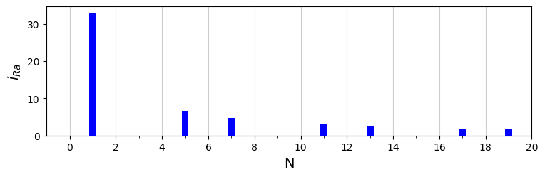

```python
import numpy as np
import matplotlib.pyplot as plt
from matplotlib.ticker import (MultipleLocator, AutoMinorLocator)
import gseim_calc as calc
from setsize import set_size

slv = calc.slv("VSI_3ph_2.in")

i_slv = 0
i_out = 0
filename = slv.l_filename_all[i_slv][i_out]
print('filename:', filename)
u1 = np.loadtxt(filename)
t1 = u1[:, 0]

g1 = slv.get_array_double(i_slv,i_out,"g1",u1)
g2 = slv.get_array_double(i_slv,i_out,"g2",u1)
g3 = slv.get_array_double(i_slv,i_out,"g3",u1)
g4 = slv.get_array_double(i_slv,i_out,"g4",u1)
g5 = slv.get_array_double(i_slv,i_out,"g5",u1)
g6 = slv.get_array_double(i_slv,i_out,"g6",u1)

# since we have stored two cycles, we need to divide the last time point
# by 2 to get the period:

T = t1[-1]/2

i_out = 1
filename = slv.l_filename_all[i_slv][i_out]
print('filename:', filename)
u2 = np.loadtxt(filename)
t2 = u2[:, 0]

v_a0 = slv.get_array_double(i_slv,i_out,"v_a0",u2)
v_b0 = slv.get_array_double(i_slv,i_out,"v_b0",u2)
v_c0 = slv.get_array_double(i_slv,i_out,"v_c0",u2)
v_ab = slv.get_array_double(i_slv,i_out,"v_ab",u2)
v_bc = slv.get_array_double(i_slv,i_out,"v_bc",u2)
v_ca = slv.get_array_double(i_slv,i_out,"v_ca",u2)
v_an = slv.get_array_double(i_slv,i_out,"v_an",u2)
v_bn = slv.get_array_double(i_slv,i_out,"v_bn",u2)
v_cn = slv.get_array_double(i_slv,i_out,"v_cn",u2)
v_n0 = slv.get_array_double(i_slv,i_out,"v_n0",u2)

i_out = 2
filename = slv.l_filename_all[i_slv][i_out]
print('filename:', filename)
u3 = np.loadtxt(filename)
t3 = u3[:, 0]

IRa  = slv.get_array_double(i_slv,i_out,"IRa",u3)
IRb  = slv.get_array_double(i_slv,i_out,"IRb",u3)
IRc  = slv.get_array_double(i_slv,i_out,"IRc",u3)
IS1  = slv.get_array_double(i_slv,i_out,"IS1",u3)
P_Ra = slv.get_array_double(i_slv,i_out,"P_Ra",u3)
P_Rb = slv.get_array_double(i_slv,i_out,"P_Rb",u3)
P_Rc = slv.get_array_double(i_slv,i_out,"P_Rc",u3)

# compute Fourier coeffs:

t_start = T
t_end = 2.0*T

n_fourier = 20

coeff_v_an, thd_v_an = calc.fourier_coeff_1C(t2, v_an,
    t_start, t_end, 1.0e-8, n_fourier)

coeff_IRa, thd_IRa = calc.fourier_coeff_1C(t3, IRa,
    t_start, t_end, 1.0e-8, n_fourier)

print("THD (IRa): ", "%5.2f"%(thd_IRa*100.0), "%")
print("I_Ra fundamental: RMS value: ", "%11.4E"%(coeff_IRa[1]/np.sqrt(2.0)))
print("V_an fundamental: RMS value: ", "%11.4E"%(coeff_v_an[1]/np.sqrt(2.0)))

x = np.linspace(0, n_fourier, n_fourier+1)

y_IRa = np.array(coeff_IRa)

fig, ax = plt.subplots()
plt.subplots_adjust(wspace=0, hspace=0.0)
grid_color='#CCCCCC'

set_size(6, 2, ax)

delta = 2.0
x_major_ticks = np.arange(0.0, (float(n_fourier+1)), delta)
x_minor_ticks = np.arange(0.0, (float(n_fourier+1)), 1.0)

ax.set_xlim(left=-1.0, right=float(n_fourier))
ax.set_xticks(x_major_ticks)
ax.set_xticks(x_minor_ticks, minor=True)
ax.grid(visible=True, which='major', axis='x', color=grid_color, linestyle='-', zorder=0)

ax.set_ylabel('$i_{Ra}$', fontsize=14)
ax.set_xlabel('N', fontsize=14)

bars2 = ax.bar(x, y_IRa, width=0.3, color='blue', label="$i_{Ra}$", zorder=3)

plt.tight_layout()
plt.show()
```

This notebook was contributed by **Prof. Nakul Narayanan K**, Govt. Engineering College, Thrissur. He may be contacted at nakul@gectcr.ac.in.